# Curs d’introducció a R

17 de desembre de 2018

## Introducció

> "Essentially, all models are wrong, but some are useful"

> George Box
- El model l'imposo jo, i vull saber si les dades són compatibles amb aquest model
- "A veure què surt" no sol ser una bona idea
- En medicina, un model no només ha d'ajustar bé les dades, sinó que també ha de ser interpretable
- En borsa per exemple no cal: només cal saber quan pujarà, no perquè pujarà
- En medicina està bé saber si algú tindrà una malaltia i les raons.
- És molt important destriar les variables que tenen efecte de les que no.
- És essencial provar el model amb **dades noves**, de manera que puguem calcular la fiabilitat de forma objectiva.
- Tot això ho fem amb la selecció de model

## Bias - Variance tradeoff

- "Bias": error a causa d'escollir un model erroni que no reflecteixi informació rellevant sobre les dades ("**underfitting**")
  - Les dades eren cúbiques i jo he escollit un model lineal
- "Variance": Error a causa d'ajustar *massa* el model a les dades, de manera que no generalitza correctament ("**overfitting**")
  - He escollit un model cúbic però en necessitava un de linea.
  - He ajustat un model tant a les meves dades, que quan me n'arriben de noves no funciona bé.
  - He fet servir les 40 variables que tenia, però resulta que amb 6 en tenia prou.

## Bias

Faig un model lineal:

```r
model_lineal = lm(data=data, y~x)
summary(model_lineal)
```

```
##
## Call:
## lm(formula = y ~ x, data = data)
##
## Residuals:
##      Min       1Q   Median       3Q      Max
## -2.98507 -0.61261  0.07352  0.71173  2.47019
##
## Coefficients:
##             Estimate Std. Error t value Pr(>|t|)
## (Intercept) 2.330674   0.203023  11.480  < 2e-16 ***
## x           0.027944   0.003456   8.086 1.66e-12 ***
## ---
## Signif. codes:  0 '***' 0.001 '**' 0.01 '*' 0.05 '.' 0.1 ' ' 1
##
## Residual standard error: 1.008 on 98 degrees of freedom
## Multiple R-squared:  0.4002, Adjusted R-squared:  0.3941
## F-statistic: 65.38 on 1 and 98 DF,  p-value: 1.664e-12
```

## Visualització

[figure not shown]

## Model més complex

```
##
## Call:
## lm(formula = y ~ log(x), data = data)
##
## Residuals:
##      Min       1Q   Median       3Q      Max
## -2.32014 -0.60319  0.00486  0.58124  2.29109
##
## Coefficients:
##             Estimate Std. Error t value Pr(>|t|)
## (Intercept)  0.09628    0.36746   0.262    0.794
## log(x)       1.00346    0.09767  10.274   <2e-16 ***
## ---
## Signif. codes:  0 '***' 0.001 '**' 0.01 '*' 0.05 '.' 0.1 ' ' 1
##
## Residual standard error: 0.9028 on 98 degrees of freedom
## Multiple R-squared:  0.5186, Adjusted R-squared:  0.5136
## F-statistic: 105.6 on 1 and 98 DF,  p-value: < 2.2e-16
```

## Visualització

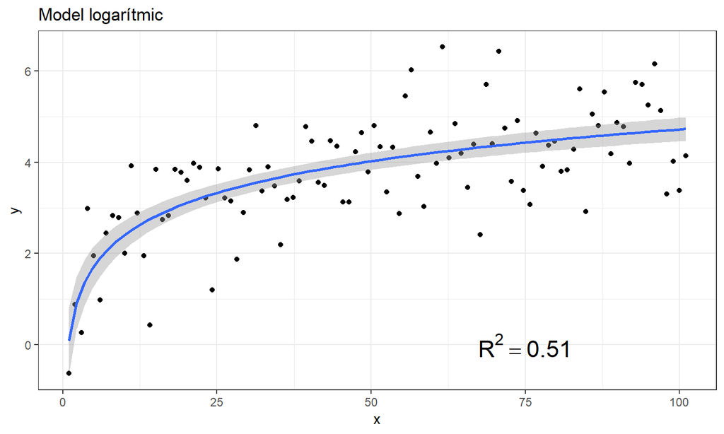

## Variància

Ajusto un model gairebé perfecte, un polinomi de grau 16:

```r
model_poli = lm(data = data, y~poly(x, degree=16))
```

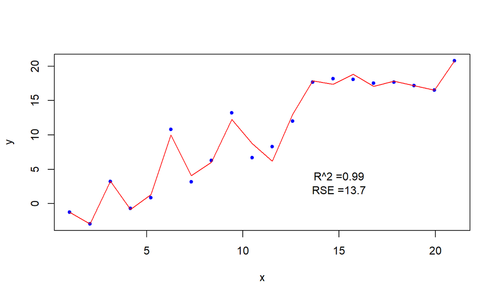

## Què passa quan generalitzem

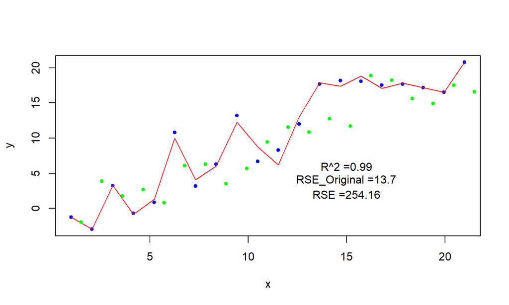

## Amb una regressió lineal

```
##
## Call:
## lm(formula = y ~ x, data = data)
##
## Residuals:
##    Min     1Q Median     3Q    Max
## -3.913 -2.688 -0.602  2.197  6.081
##
## Coefficients:
##             Estimate Std. Error t value Pr(>|t|)
## (Intercept)  -2.4583     1.4386  -1.709    0.105
## x             1.1478     0.1145  10.024 8.61e-09 ***
## ---
## Signif. codes:  0 '***' 0.001 '**' 0.01 '*' 0.05 '.' 0.1 ' ' 1
##
## Residual standard error: 3.108 on 18 degrees of freedom
## Multiple R-squared:  0.8481, Adjusted R-squared:  0.8396
## F-statistic: 100.5 on 1 and 18 DF,  p-value: 8.611e-09
```

## Generalització

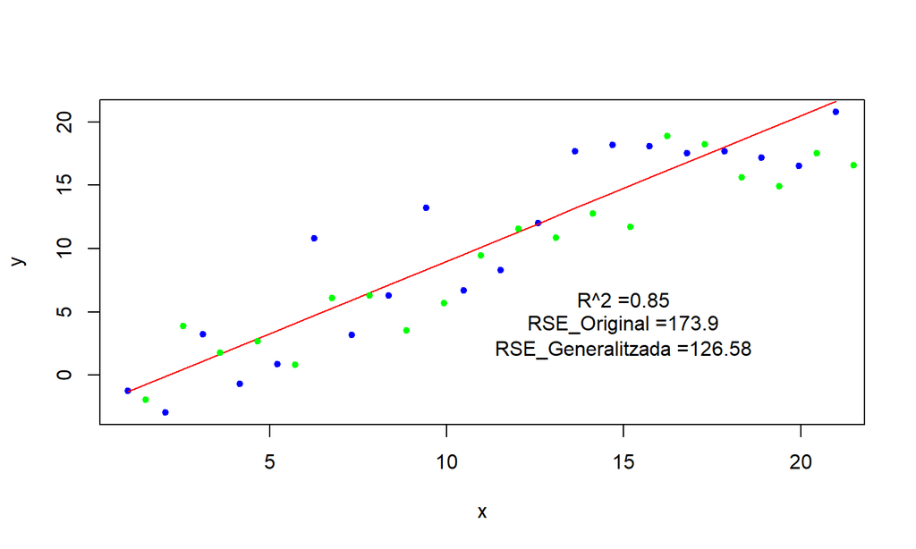

## No sempre és veritat!

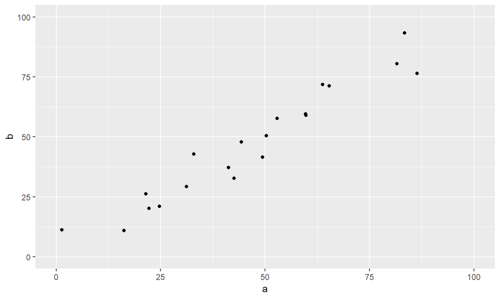

## Com aquí

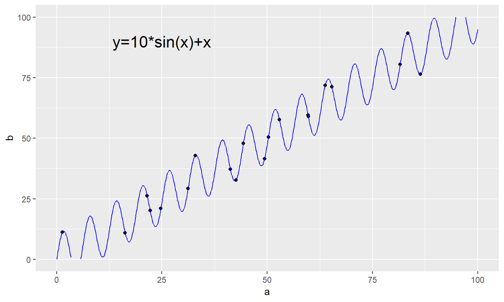

## En classificació

- Encara es veu més clar en classificació
- Proposem tres línies de decisió en les mateixes dades

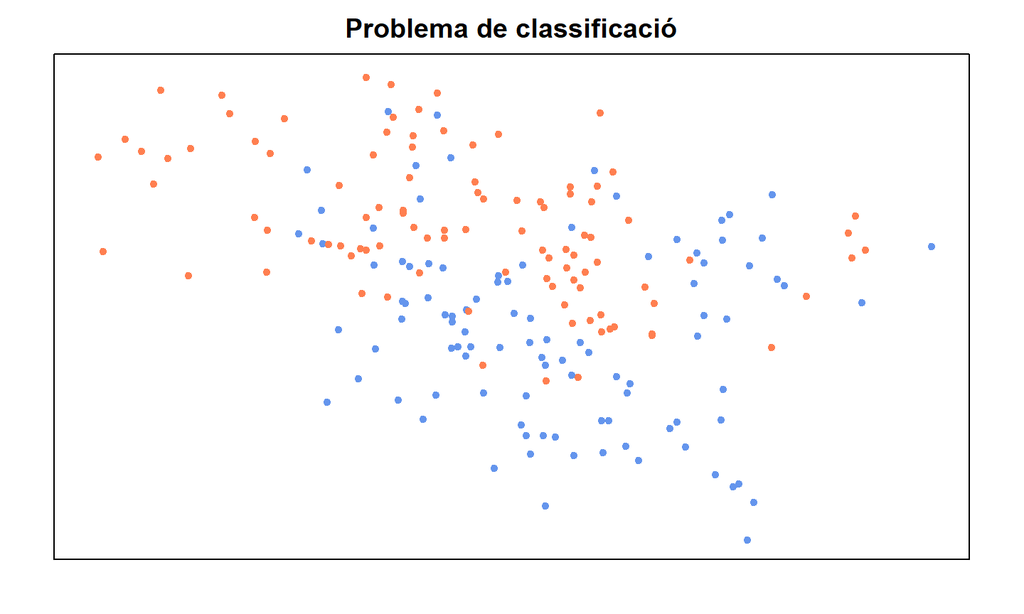

## Overfitting

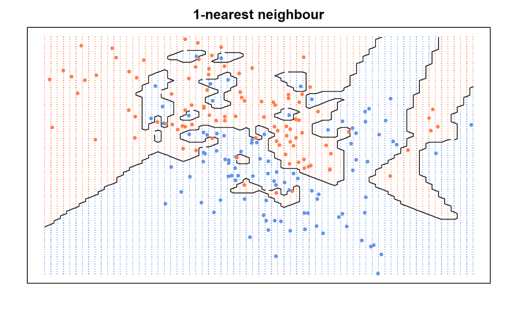

## Underfitting

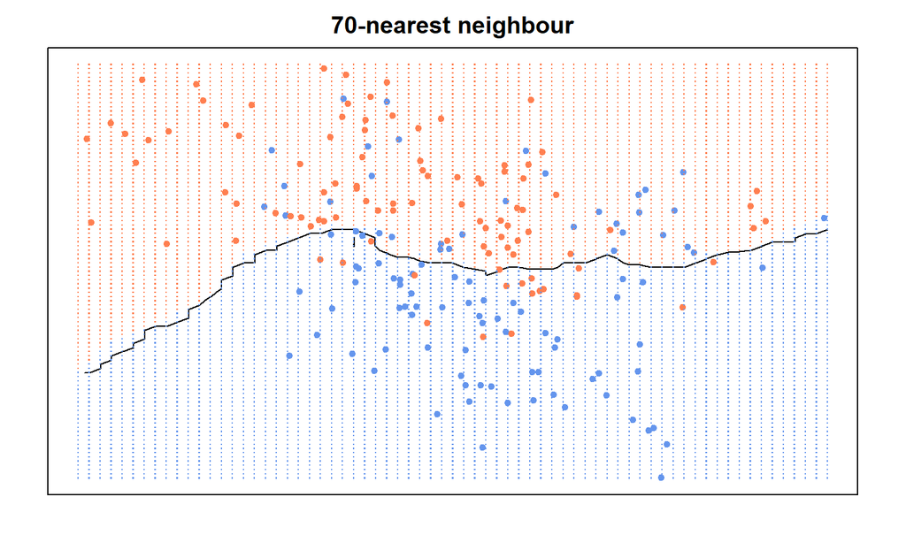

## Òptim?

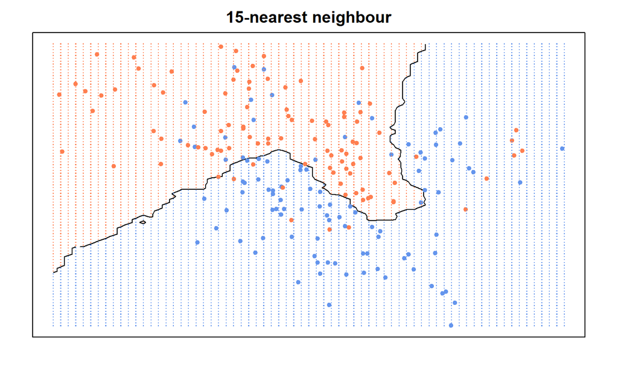

## Resum

- En medicina la gran majoria de vegades volem models lineals.
- La regressió logística és un molt bon model.
  - És simple i lineal.
  - És interpretable.
  - Podem calcular la corba ROC i la AUC.
- Els models d'arbre són simples i interpretables però tendeixen a tenir "overfitting".
- Per sol·lucionar-ho podem fer *random forests* o *boosted models*, però són molt poc interpretables.
- En casos de models multinomials (més de dues possibilitats) també s'utilitza força el "*linear discriminant analysis*"

## Selecció de model multivariant

- Tinc un model amb moltes possibles variables predictores.
- Vull trobar quines són predictores de veritat i quines no.
- Opció "tradicional": mirar quins són significatius univariadament i després posar-los tots ens un model multivariant.
- A causa de colinealitats pot ser que aquest mètode no funcioni.
- Hi ha diverses possibilitats, en veurem dues:
- Forward subset selection
- Lasso

## Valors evaluadors de models

- Fins ara hem evaluat els models amb \(R^2\), però hi ha problemes.
- Si afegeixo dimensions \(R^2\) augmenta, tant si aquestes ajuden al model com si no.
- Alternatives
  - \(R^2\) ajustat
  - Akaike Information Criterion: AIC
  - Bayesian Information Criterion: BIC
  - Mallow's Cp
  - Cross-validation: calcul·lo el model en un subconjunt de les dades i el provo en l'altre -> Trio el millor model.

## Forward subset selection

- Volem mirar els models possibles, però el númeor de models és de l'orde de \(2^d\), on d és el número de dimensions.
- Per això apliquem FSS: Comencem amb 0 predictors i anem afegint el millor predictor a cada pas.
- Quan el següent millor predictor ja no millora el model, parem de buscar.
- Alerta: hi ha una (petita) probabilitat de no trobar el millor model.

## A la pràctica

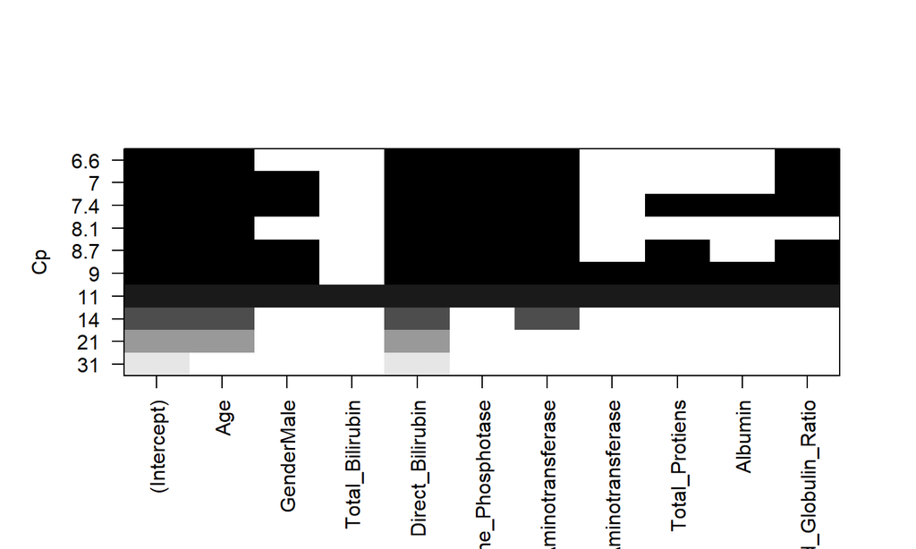

```r
ffs_model = regsubsets(Malaltia ~., data=liver, nvmax=10, method = "forward")
plot(ffs_model, scale = "Cp")
```

```r
#summary(ffs_model)
```

## Lasso (amb cross-validació)

- Lasso és un mètode semblant a l'anterior però que elimina les variables no útils d'una forma contínua.
- Intenta fer petits els coeficients sense que se'n ressenti el model.
- Alguns dels coeficients arriben a ser 0 i per tant podem eliminar les variables.
- Va molt bé per simplificar models.
- Escull el millor model amb cross-validació
- n-fold cross-validation divideix el model en n conjunts, entrena models en n-1 d'aquests i els prova en l'altre.
- La mitja de l'error de les 10 proves és l'error del model.
- Ho fa per tots els models possibles i ens retorna el millor.

\[ \min \left\{ \frac{1}{n}||y-X\beta||_2^2+\lambda ||\beta_1|| \right\} \]

## Lasso en R

Els coeficients són:

```
##                (Intercept)                        Age
##                0.020231939               -0.007475957
##                 GenderMale           Direct_Bilirubin
##               -0.161001238               -0.257206258
##       Alkaline_Phosphotase   Alamine_Aminotransferase
##               -0.001468039               -0.002566690
##                    Albumin Albumin_and_Globulin_Ratio
##                0.037120231                0.230395002
```

El percentatge d'encert és 75%.

## Comparerm amb una RL "normal"

Els coeificients són:

```
##                (Intercept)                        Age
##               2.8904434188              -0.0158011781
##                 GenderMale            Total_Bilirubin
##              -0.2204567561               0.3586522972
##           Direct_Bilirubin       Alkaline_Phosphotase
##              -1.2288995719              -0.0020527280
##   Alamine_Aminotransferase Aspartate_Aminotransferase
##              -0.0128842926              -0.0006870516
##             Total_Protiens                    Albumin
##              -0.6322783415               1.2469796192
## Albumin_and_Globulin_Ratio
##              -1.4459331894
```

El percentatge d'encert és 73.3%.